## Current Projects

#### Zhiyan Gao

##### June 10, 2019

- **Perception of Foreign Accentedness** (with Prof. Steven Weinberger)  
  This project focused on native English speakers’ perception of L2 speech errors. L2 errors were ranked according to their perceptual accentedness. A Naive Discrimination Model (NDL) was build to approximate accentedness. Preliminary results were published [here](https://content.sciendo.com/view/journals/rela/16/2/article-p135.xml). A [web application](https://gaozhiyan.shinyapps.io/ndl_calculator/) was developed to implement the NDL method.
- **Crowd-sourcing Tools for Phonetic Transcriptions** (with Prof. Steven Weinberger, Prof. Jill Nelson & Dr. Steven Kunath)  
  This project developed an online web interface that allows a great number of people to transcribe short English utterances. The tool itself facilitates the learning of phonetics symbols. The differences and similarities between transcribers provide great insights into speech perception. By observing multiple submissions of the same group of transcribers, one could further investigate various learning theories. Try out the web tool [here](http://www.phonetictranscriber.org/)
- **The effect of language experience on lexical tone perception** (with Dr. Xianzhuo Li)  
  The current study focused on the identification and discrimination of Mandarin lexical tones by 3 groups of listeners, namely, native speakers of Mandarin Chinese (tonal language), native speakers of Lao (tonal language), and native speakers of Uzbek (non-tonal language). Native mandarin speakers were better at Mandarin tone discrimination than Lao speakers, who were better than Uzbek speakers. There also seems to be an ordering effect with regard to the presentation of the stimuli. Preliminary results were reported at the 176th meeting of the Acoustical Society of America. Further results are still pending.
- **Comparisons between Nantong Chinese and Middle Chinese**  
  Nantong Chinese is my native language, with approximately one million native speakers according to a 2010 census report. Middle Chinese was a language spoken in 7th century China. It has long been a tradition in Chinese historical linguistics to assume that most varieties of modern Chinese dialects are, to some degree, descendants of Middle Chinese. Following such a tradition, I developed a [web application](https://nantonghua.shinyapps.io/nantonghua/) to observe how Middle Chinese phonemes morphed into Nantong Chinese phonemes. I am not a historical linguist. This project was conducted purely for fun.

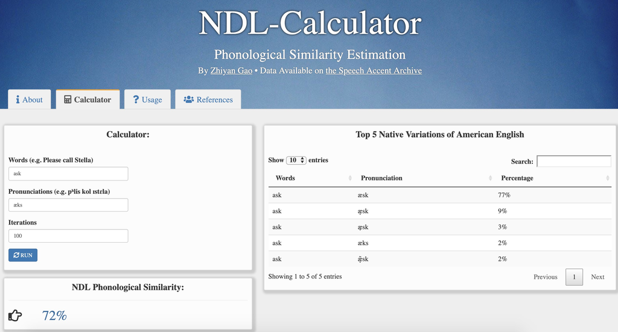

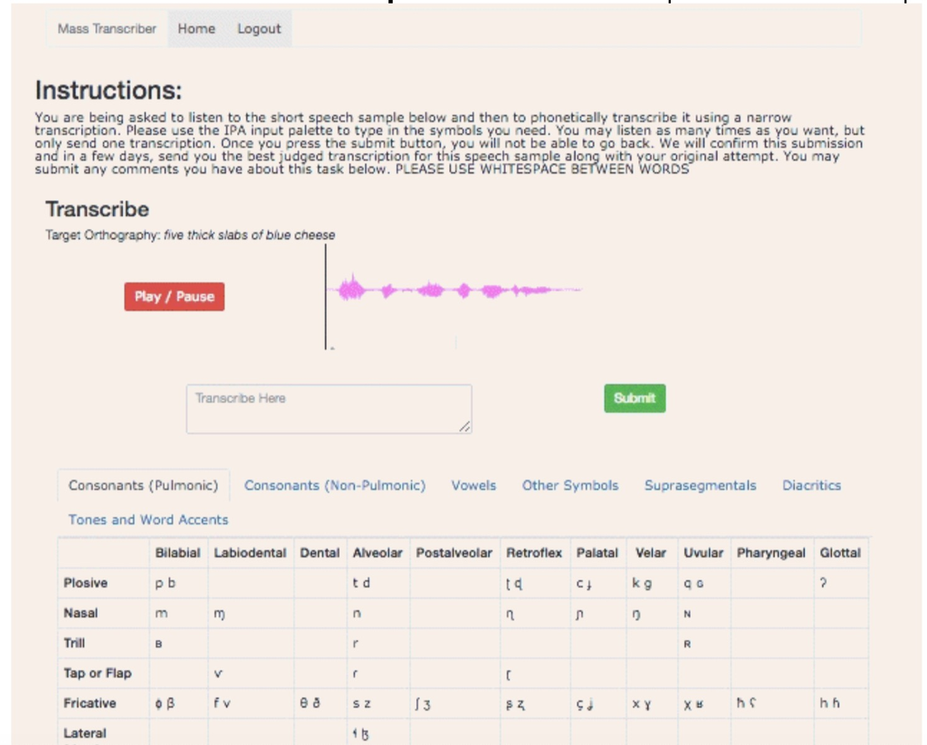

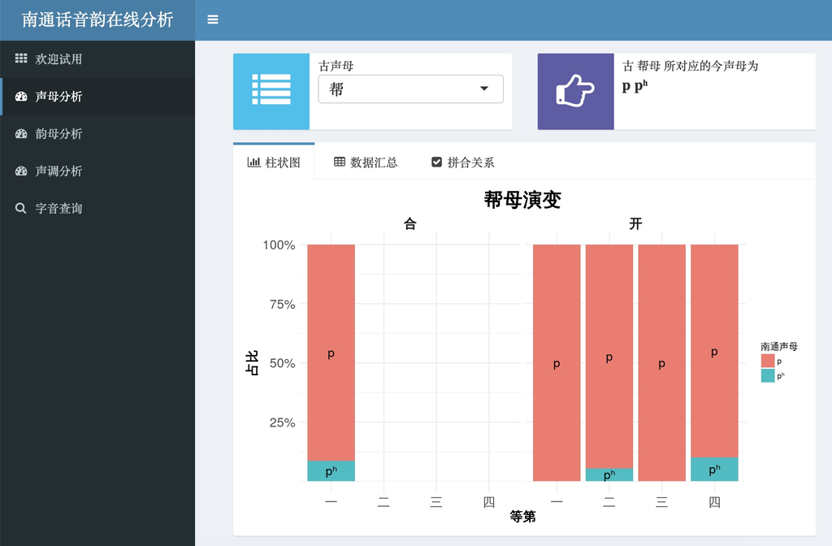

[NDL Calculator](https://gaozhiyan.shinyapps.io/ndl_calculator)

[Mass Transcribers](http://www.phonetictranscriber.org/)

[Nantong Chinese](https://nantonghua.shinyapps.io/nantonghua/)